## **2016 USA Presidential Campaign Finance Analysis**

### **Abstract**

The purpose of this analysis is to understand from where the 2016 US Presidential Elections’ contributions are coming, which are the most common characteristics of the average contributor’s profile, which candidate receives the highest amount of contributions and the amount received by party and state, so the Parties could drive their efforts based on data and information instead of other methods.

### **Introduction**

The United States of America’s Presidential Election is [the most important election among all nations](https://www.quora.com/Why-is-United-States-Presidential-election-important-to-other-nations).

Two interesting facts about US Presidential Elections:

1. US has a dual party Democracy, although there are other parties that are part of it
2. The campaigns are mostly privately funded but public financing is available as well

**Source:** Wikipedia on [“Campaign Finance in the United States”](https://en.wikipedia.org/wiki/Campaign_finance_in_the_United_States)

This analysis will be focused on financial information disclosed by each presidential candidate who has reported at least $100,000 in contributions from individuals other than the candidate.

This dataset is provided by the **United States Federal Election Commission (FEC)**, and it includes data for all individual contributions reported on Form 3P Line 17A, refunds to individuals reported on Form 3P Line 28A and transfers from authorized committees reported on Form 3P Line 18, together with geographical data, so it is possible to dive into details like donation by City and ZIP Code.

Dataset source: [Federal Election Commission - 2016 Presidential Campaign Finance](https://cg-519a459a-0ea3-42c2-b7bc-fa1143481f74.s3-us-gov-west-1.amazonaws.com/bulk-downloads/Presidential_Map/2016/P00000001/P00000001-ALL.zip)

### **Dataset Analysis**

```
## 'data.frame':    7440252 obs. of  18 variables:
##  $ cmte_id          : chr  "C00458844" "C00458844" "C00458844" "C00458844" ...
##  $ cand_id          : Factor w/ 25 levels "P00003392","P20002671",..: 11 11 11 11 11 11 11 11 11 11 ...
##  $ cand_nm          : Factor w/ 25 levels "Bush, Jeb","Carson, Benjamin S.",..: 19 19 19 19 19 19 19 19 19 19 ...
##  $ contbr_nm        : Factor w/ 1393128 levels "'CALL, ALLAN",..: 112879 318178 213391 1077550 1077550 789174 318874 213391 1027867 537615 ...
##  $ contbr_city      : Factor w/ 26456 levels "","'CALLAHAN",..: 24977 1044 6102 780 780 6102 780 6102 780 780 ...
##  $ contbr_st        : Factor w/ 116 levels "20","30","AA",..: 1 2 5 5 5 5 5 5 5 5 ...
##  $ contbr_zip       : Factor w/ 871835 levels "",".","`1136",..: 871767 871771 92745 92485 92485 92710 92704 92745 152 92481 ...
##  $ contbr_employer  : Factor w/ 399182 levels "","''I LIKE COMICS''",..: 334165 234488 101162 372773 372773 98147 102964 101162 144561 292072 ...
##  $ contbr_occupation: Factor w/ 127674 levels "","''''FOR HIRE'''' DRIVER",..: 77537 86545 120534 82249 82249 46214 114905 120534 8157 96806 ...
##  $ contb_receipt_amt: num  175 25 100 200 100 ...
##  $ contb_receipt_dt : Factor w/ 849 levels "01-APR-15","01-APR-16",..: 396 424 528 261 208 179 703 146 478 800 ...
##  $ receipt_desc     : Factor w/ 203 levels ""," SEE REATTRIBUTION",..: 1 1 1 1 1 1 1 1 1 1 ...
##  $ memo_cd          : Factor w/ 2 levels "","X": 1 1 1 1 1 1 1 1 1 1 ...
##  $ memo_text        : Factor w/ 1721 levels ""," SEE REATTRIBUTION",..: 1 992 1 1 1 1 1 1 992 1 ...
##  $ form_tp          : Factor w/ 3 levels "SA17A","SA18",..: 1 1 1 1 1 1 1 1 1 1 ...
##  $ file_num         : int  1082559 1082559 1056862 1082559 1082559 1082559 1029436 1056862 1082559 1047126 ...
##  $ tran_id          : Factor w/ 7289531 levels "A0000FD2A304E432AAD5",..: 3664753 3665478 3573467 3609940 3607294 3606756 4128523 3643619 3665564 4178277 ...
##  $ election_tp      : Factor w/ 11 levels "","G2015","G2016",..: 8 8 8 8 8 8 8 8 8 8 ...
```

The provided dataset contains 18 columns with 7440252 observations:

| **FIELD NAME** | **FIELD DESCRIPTION** |
| --- | --- |
| cmte_id | COMMITTEE ID |
| cand_id | CANDIDATE ID |
| cand_nm | CANDIDATE NAME |
| contbr_nm | CONTRIBUTOR NAME |
| contbr_city | CONTRIBUTOR CITY |
| contbr_st | CONTRIBUTOR STATE |
| contbr_zip | CONTRIBUTOR ZIP CODE |
| contbr_employer | CONTRIBUTOR EMPLOYER |
| contbr_occupation | CONTRIBUTOR OCCUPATION |
| contb_receipt_amt | CONTRIBUTION RECEIPT AMOUNT |
| contb_receipt_dt | CONTRIBUTION RECEIPT DATE |
| receipt_desc | RECEIPT DESCRIPTION |
| memo_cd | MEMO CODE |
| memo_text | MEMO TEXT |
| form_tp | FORM TYPE |
| file_num | FILE NUMBER |
| tran_id | TRANSACTION ID |
| election_tp | ELECTION TYPE/PRIMARY GENERAL INDICATOR |

Not all columns are required, because the data contained in them were not relevant for this study.  
Therefore, the following columns will not be used:

contbr_nm (Contributor Name)  
cand_id (Candidate ID) - For a more understandable analysis, the Candidate’s names will be used instead  
receipt_desc (Receipt Description)  
memo_cd (Memo Code)  
memo_text (Memo Text)  
file_num (File Number)  
tran_id (Transaction ID)  
contbr_employer (Contributor Employer)

Also, to make it easier to read, the following fields were renamed:

| **FIELD NAME (OLD)** | **FIELD NAME (NEW)** |
| --- | --- |
| cmte_id | committee_id |
| cand_nm | candidate_name |
| contbr_city | contributor_city |
| contbr_st | contributor_state |
| CONTBR_ZIP | contributor_zip |
| contbr_occupation | contributor_occupation |
| contb_receipt_amt | contributor_rcpt_amt |
| contb_receipt_dt | contributor_rcpt_date |
| form_tp | form_type |
| election_tp | election_type |

```
## 'data.frame':    7440252 obs. of  10 variables:
##  $ committee_id          : chr  "C00458844" "C00458844" "C00458844" "C00458844" ...
##  $ candidate_name        : Factor w/ 25 levels "Bush, Jeb","Carson, Benjamin S.",..: 19 19 19 19 19 19 19 19 19 19 ...
##  $ contributor_city      : Factor w/ 26456 levels "","'CALLAHAN",..: 24977 1044 6102 780 780 6102 780 6102 780 780 ...
##  $ contributor_st        : Factor w/ 116 levels "20","30","AA",..: 1 2 5 5 5 5 5 5 5 5 ...
##  $ contributor_zip       : Factor w/ 871835 levels "",".","`1136",..: 871767 871771 92745 92485 92485 92710 92704 92745 152 92481 ...
##  $ contributor_occupation: Factor w/ 127674 levels "","''''FOR HIRE'''' DRIVER",..: 77537 86545 120534 82249 82249 46214 114905 120534 8157 96806 ...
##  $ contributor_rcpt_amt  : num  175 25 100 200 100 ...
##  $ contributor_rcpt_date : Factor w/ 849 levels "01-APR-15","01-APR-16",..: 396 424 528 261 208 179 703 146 478 800 ...
##  $ form_type             : Factor w/ 3 levels "SA17A","SA18",..: 1 1 1 1 1 1 1 1 1 1 ...
##  $ election_type         : Factor w/ 11 levels "","G2015","G2016",..: 8 8 8 8 8 8 8 8 8 8 ...
```

The Contributor ZIP Code (**contributor_zip field**) will not be used in this study, due to its granularity. When used, the plots did not provide a clear information.  
Also, the Committee ID (**committee_id field**) will not be used, because it is directly linked to the Candidate and, since the Candidate Name will be used in the plots, it can be excluded without concerns.

Number of unique ZIP Codes:

```
## [1] 871835
```

Number of unique Committee IDs:

```
## [1] 26
```

There were 25 candidates in this election

```
## [1] 25
```

```
##  [1] Rubio, Marco              Santorum, Richard J.
##  [3] Perry, James R. (Rick)    Carson, Benjamin S.
##  [5] Cruz, Rafael Edward 'Ted' Paul, Rand
##  [7] Clinton, Hillary Rodham   Sanders, Bernard
##  [9] Fiorina, Carly            Huckabee, Mike
## [11] Pataki, George E.         O'Malley, Martin Joseph
## [13] Graham, Lindsey O.        Bush, Jeb
## [15] Trump, Donald J.          Jindal, Bobby
## [17] Christie, Christopher J.  Walker, Scott
## [19] Stein, Jill               Webb, James Henry Jr.
## [21] Kasich, John R.           Gilmore, James S III
## [23] Lessig, Lawrence          Johnson, Gary
## [25] McMullin, Evan
## 25 Levels: Bush, Jeb Carson, Benjamin S. ... Webb, James Henry Jr.
```

In the original file, [reimbursements were included as well](https://www.fec.gov/help-candidates-and-committees/taking-receipts-political-party/refunds-contributions/), but they will need to be deleted, in order not to influence statistical data (mean, median, etc.)

```
##     Min.  1st Qu.   Median     Mean  3rd Qu.     Max.
##   -93308       15       28      126       94 12777706
```

Proceeding with the deletion of contributions lower than USD 0 (reimbursements). The results are:

```
##     Min.  1st Qu.   Median     Mean  3rd Qu.     Max.
##        0       15       28      134      100 12777706
```

Since we have 50 states in USA plus 1 Federal District (DC) and the dataset has 116 states, a data transformation will be required: renaming all states not belonging to USA to ‘OT’ -> Others

```
##  [1] AK AL AR AZ CA CO CT DC DE FL GA HI IA ID IL IN KS KY LA MA MD ME MI
## [24] MN MO MS MT NC ND NE NH NJ NM NV NY OH OK OR OT PA RI SC SD TN TX UT
## [47] VA VT WA WI WV WY
## 52 Levels: AK AL AR AZ CA CO CT DC DE FL GA HI IA ID IL IN KS KY LA ... WY
```

Contributors from 51 States (including DC) + “Others” contributed to this election as well.  
Number of states:

```
## [1] 52
```

State names:

```
##  [1] OT AK AL AR AZ CA CO CT DC DE FL GA HI IA ID IL IN KS KY LA MA MD ME
## [24] MI MN MO MS MT NC ND NE NH NJ NM NV NY OH OK OR PA RI SC SD TN TX UT
## [47] VA VT WA WI WV WY
## 52 Levels: AK AL AR AZ CA CO CT DC DE FL GA HI IA ID IL IN KS KY LA ... WY
```

The main attributes of this dataset are: **Candidate Name, Contributor City, Contributor State and Receipt Amount.**

Besides the Candidate’s Name, the Contributor City and State are important to identify which region of the Country contributes (US$) most, so campaigns could be handled differently based on this fact.

Other attributes that might help to identify patterns or uncommon distributions are **Form Type** and **Receipt Date.**  
The Form Type column indicates what schedule and line number the reporting committee reported a specific transaction:

**- SA17A: Form 3P Schedule A Line 17A –> Individual contributions**  
**- SA18: Form 3P Schedule A Line 18 –> Transfers from authorized committees**  
**- SB28A: Form 3P Schedule B Line 28A –> Refunds to individuals**

Still regarding this dataset, three new variables were created:

| **FIELD NAME** | **FIELD DESCRIPTION** | **DATA** |
| --- | --- | --- |
| candidate_gender | CANDIDATE GENDER | **M (Male) \| F (Female)** |
| candidate_party | CANDIDATE PARTY | **L** \| **G** \| **I** \| **D** \| **R** |
| candidate_party_nm | PARTY NAME | **L**ibertarian, \| **G**reen \| **I**ndependent \| **D**emocrats \| **R**epublicans |

Top 10 summary count of contributor occupations that mostly contributed:

```
##               (Other)               RETIRED          NOT EMPLOYED
##               4163109               1644675                625585
## INFORMATION REQUESTED              ATTORNEY               TEACHER
##                245077                196897                139322
##             PHYSICIAN             HOMEMAKER             PROFESSOR
##                116867                105165                102899
##                  NA's
##                  1119
```

Top 10 summary count of contributions by City:

```
##       (Other)      NEW YORK   LOS ANGELES SAN FRANCISCO    WASHINGTON
##       6544395        203830        101488         89941         88872
##      BROOKLYN       SEATTLE       CHICAGO       HOUSTON          NA's
##         86605         81794         74777         69010             3
```

# Univariate Plots Section

**Summary count of contributions by candidate:**

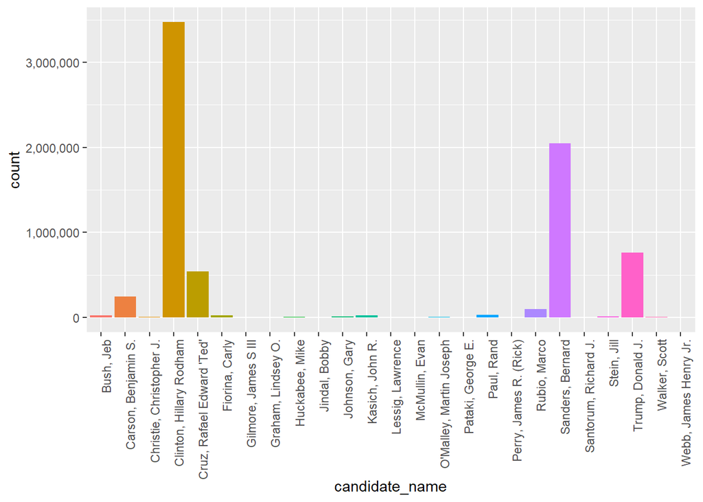

**Summary count of contributions –> by type of contribution (Form Type):**

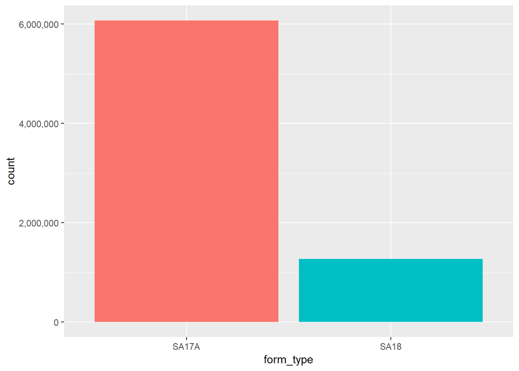

Quick reminder about form types:  
- SA17A: Individual contributions  
- SA18: Transfers from authorized committees  
- SB28A: Refunds to individuals  
**Summary count of contributions by Party**

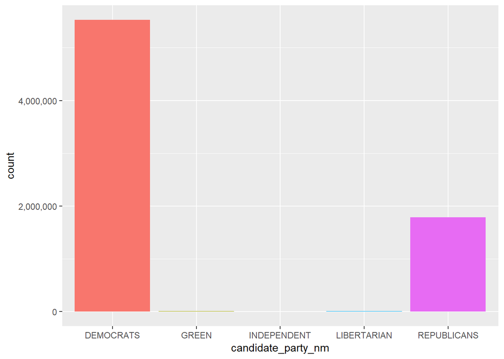

**Summary count of contributions per State**

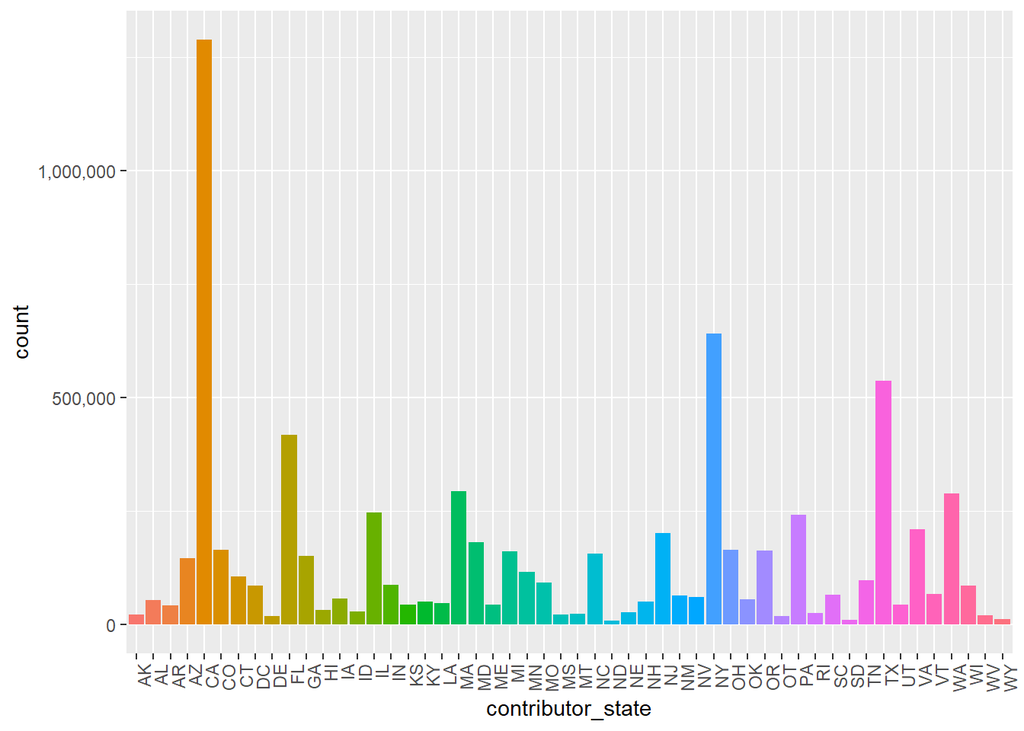

# Univariate Analysis

# Bivariate Plots Section

**Total contributions by State**

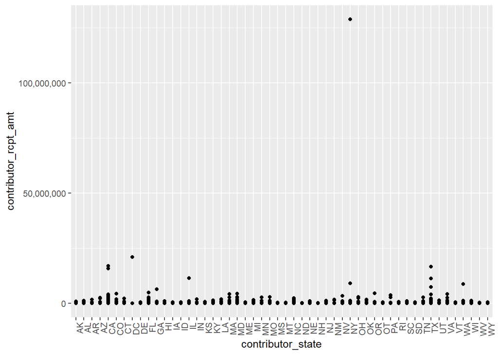

In the plot above there is an outlier, that will not be show in the next plot

**The contribution’s mean is shown below in red, and the median in green**

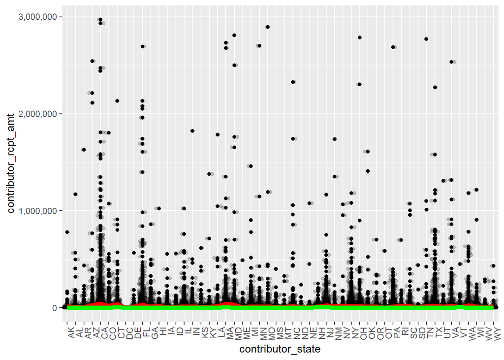

**By selecting all contributions below USD 25,000, the mean and median become clearer:**

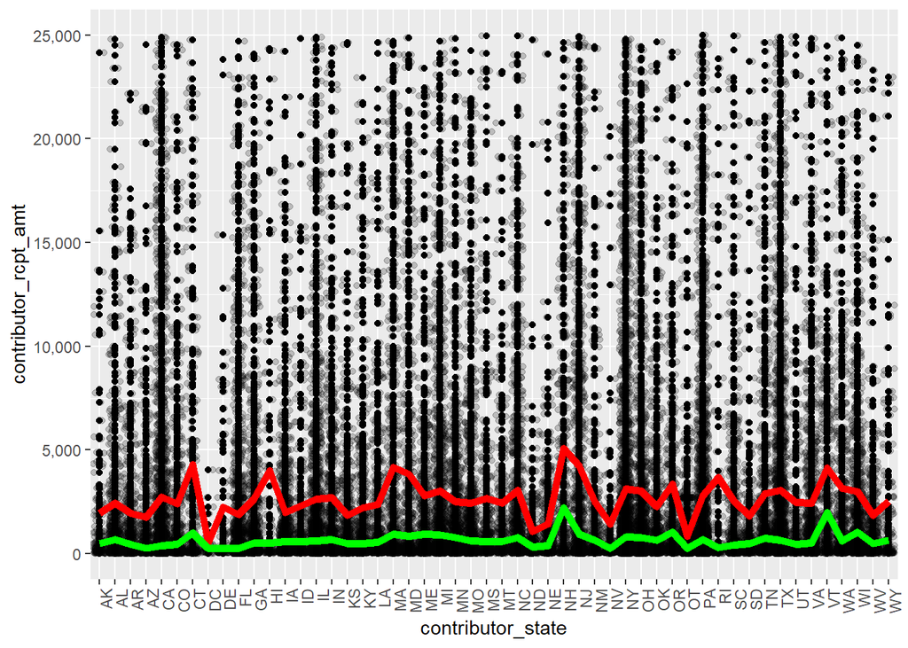

**Top 20 contributions (USD) by City**

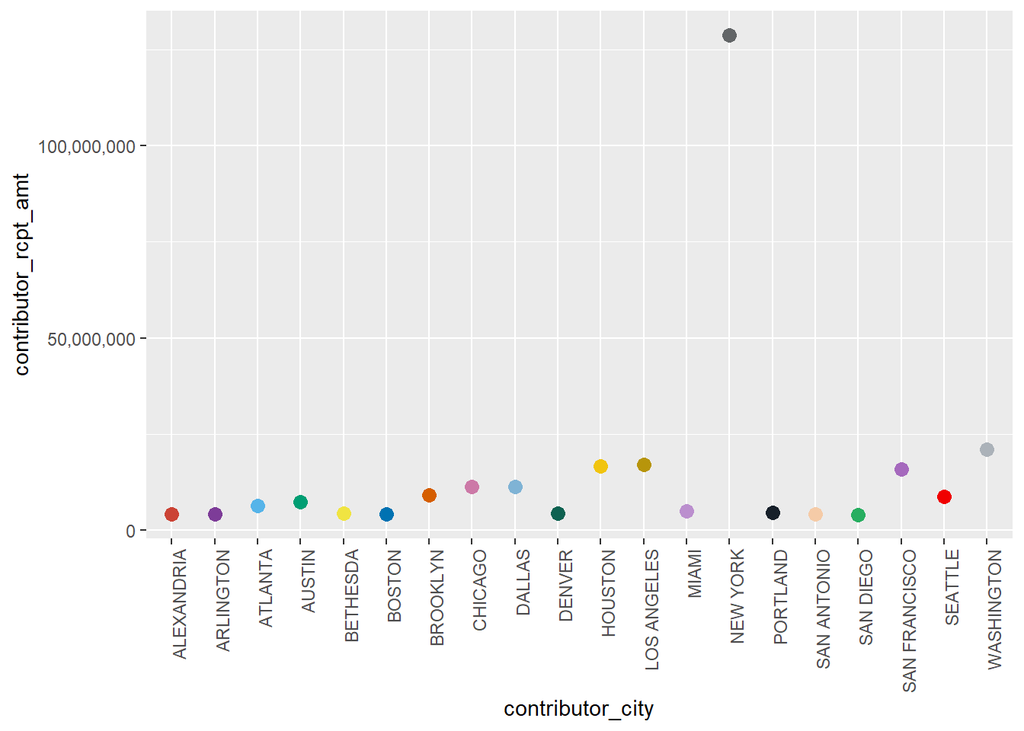

**Candidates whom received more contributions**

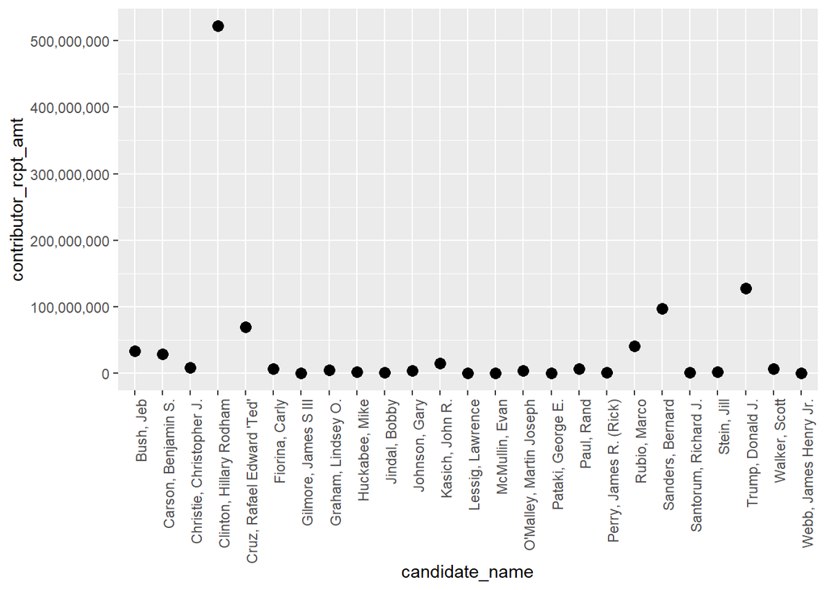

**Contribution total by type (Form Types)**

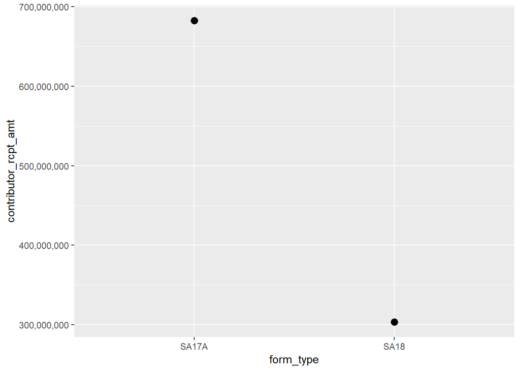

# Bivariate Analysis Section

Contribution by State: there are some outliers (i.e. individual contributions above USD 1 million), but when considering contributions below USD 25,000, the mean and median become clearer:

```
##      Min.   1st Qu.    Median      Mean   3rd Qu.      Max.
##       0.8     160.0     800.0   16927.6    4888.0 2963744.3
```

```
##                   candidate_name    form_type contributor_state
## candidate_name       1.000000000  0.134932771       0.006945827
## form_type            0.134932771  1.000000000      -0.004460731
## contributor_state    0.006945827 -0.004460731       1.000000000
## candidate_party      0.181023189  0.257669995       0.056503377
##                   candidate_party
## candidate_name         0.18102319
## form_type              0.25766999
## contributor_state      0.05650338
## candidate_party        1.00000000
```

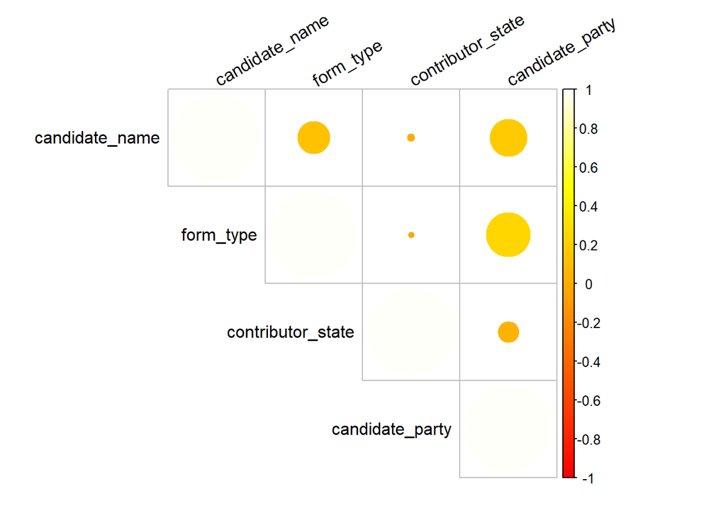

# Multivariate Plots

**Total contributions by candidate and State**

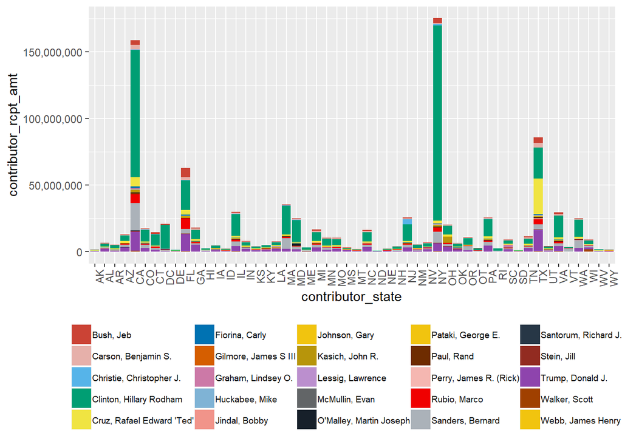

**Total contributions by contribution type and State**

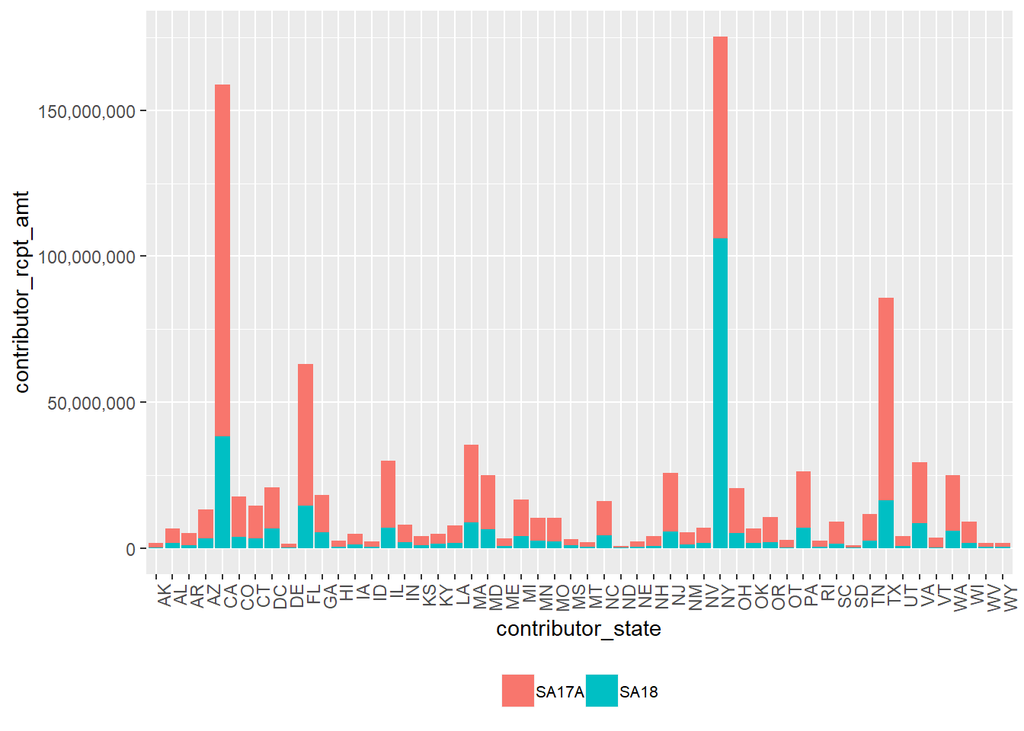

**Total contributions by candidate gender and State**

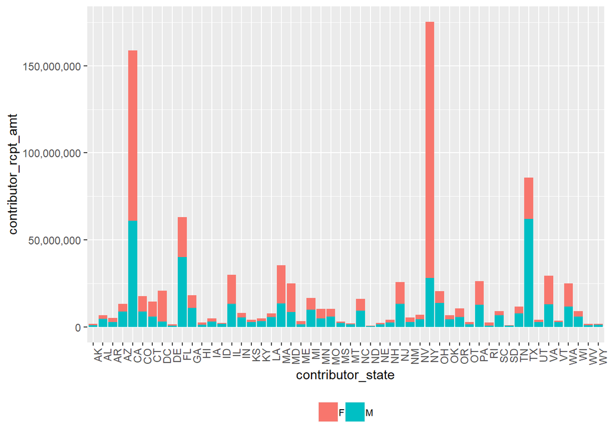

**Total contributions by Party and State**

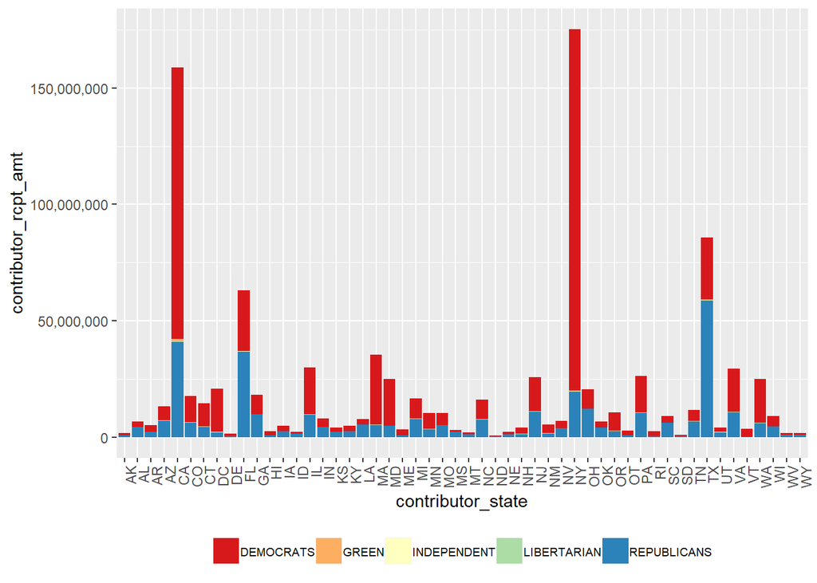